# Dynamic Network Exploration

## Exploratory Data Analysis of the Temporal Direct Network Data

We are running exploratory data analyses of the French transfer networks. OUr data comes from the direct transfers of all France hospitals in 2024, all within a 7-day time frame aggregation within one year. Therefore, our first analysis would be a descriptive analyses of the basic network characteristics.

### Weekly Transfer Window Data

Let’s explore the direct transfers with 7-day (weekly) time window,starting for all year timespan.

### Temporal Analysis of Trends by Weekly Time Window

Looking at the averages and summary statistics trend for day-to-day trends to see the ups and downs of the number of nodes, edges, transfers, and otehers

### Calculate the centrality measures statistics for the network data

## Network metrics definitions (weighted, directed hospital transfer network)

**Context (applies to all metrics):** Let (G_t = (V_t, E_t)) be the **directed, weighted** hospital transfer network for time window (t).

### `n_nodes` — Number of active nodes

**Definition:** [ n_nodes(t) = |V_t|] **Interpretation:** Number of hospitals that appear in the network during window (t) (as an origin and/or target with at least one transfer).

### `n_edges` — Number of directed edges

**Definition:** [ n_edges(t) = |E_t|] where each directed pair ((i j)) with (w_{ij,t} > 0) counts as one edge.

**Interpretation:** Number of distinct **origin → destination** transfer connections observed in window (t), regardless of volume.

### `median_weight` — Median edge weight

**Definition:** The median of the set ({w_{ij,t} : (i j)E_t}).

**Interpretation:** Typical transfer volume per observed directed connection, less sensitive to extreme high-volume routes than `mean_weight`.

### `density` — Directed network density (unweighted definition)

- Values near 0: sparse network (few observed routes).
- Values near 1: highly connected network (many observed routes).

**Note:** This density is **about presence/absence of edges**, not transfer volume. Even in a weighted network, density is usually defined on the binary graph.

### Optional clarifications (if you want to include in your Rmd)

- **Directed:** (i j) is different from (j i).
- **Weighted:** edges carry magnitudes (number of transfers).
- **Active node:** a hospital with at least one incoming or outgoing transfer in that window.
- **Edge counted once per pair per window:** multiple transfers on the same route contribute to the weight, not to additional edges.

## Graphing all the Stats

```
<img src=\data:…
```

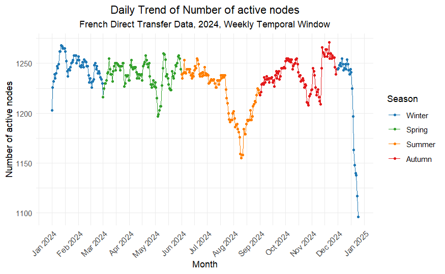

```
<img src=\data:…
```

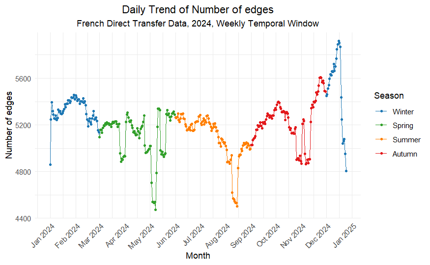

```
<img src=\data:…
```

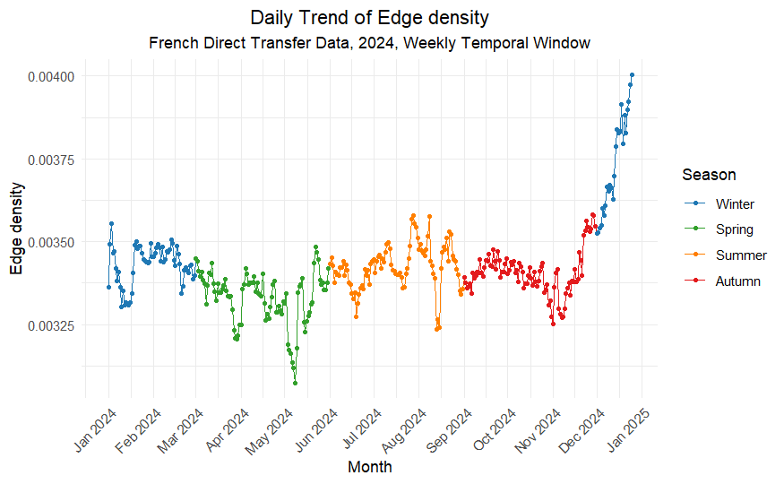

```
<img src=\data:…
```

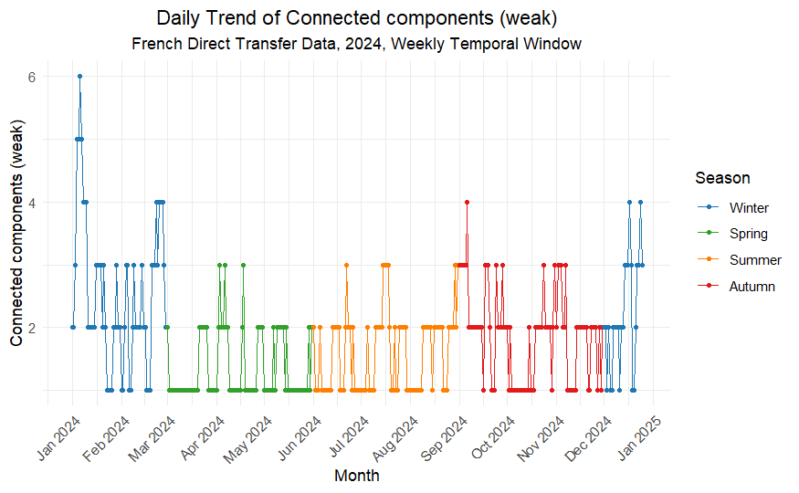

```
<img src=\data:…
```

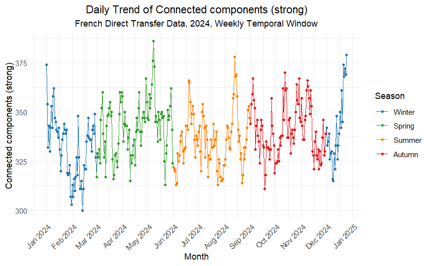

```
<img src=\data:…
```

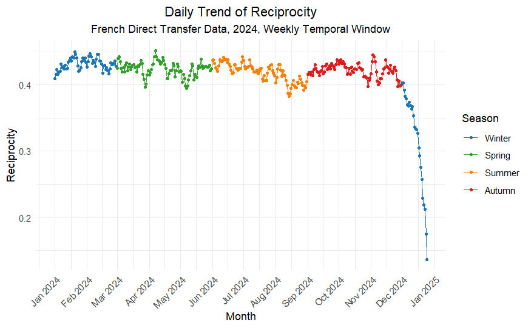

```
<img src=\data:…
```

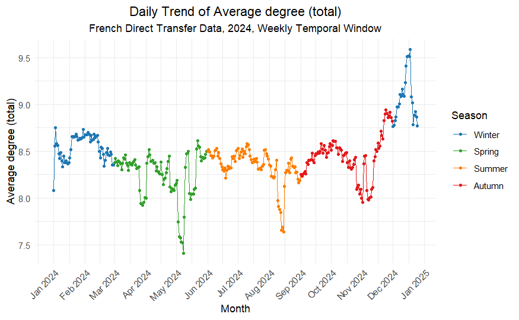

```
<img src=\data:…
```

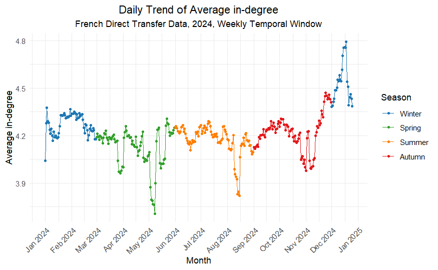

```
<img src=\data:…
```

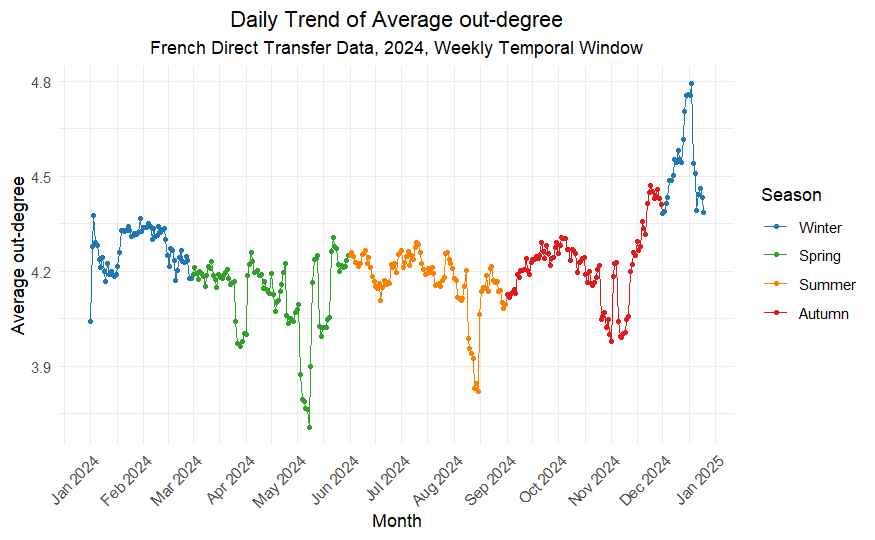

```
<img src=\data:…
```

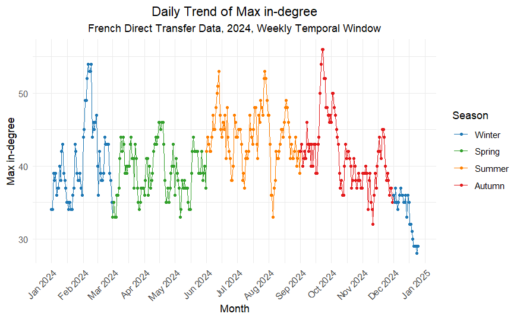

```
<img src=\data:…
```

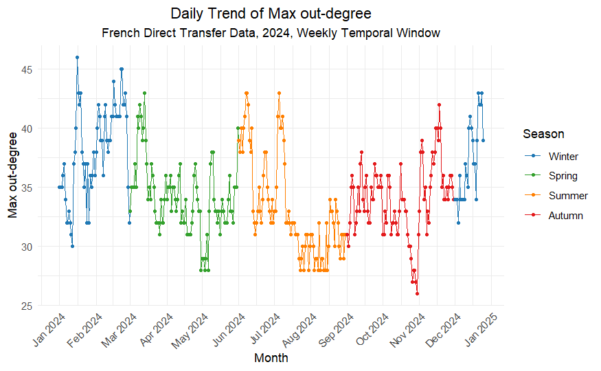

```
<img src=\data:…
```

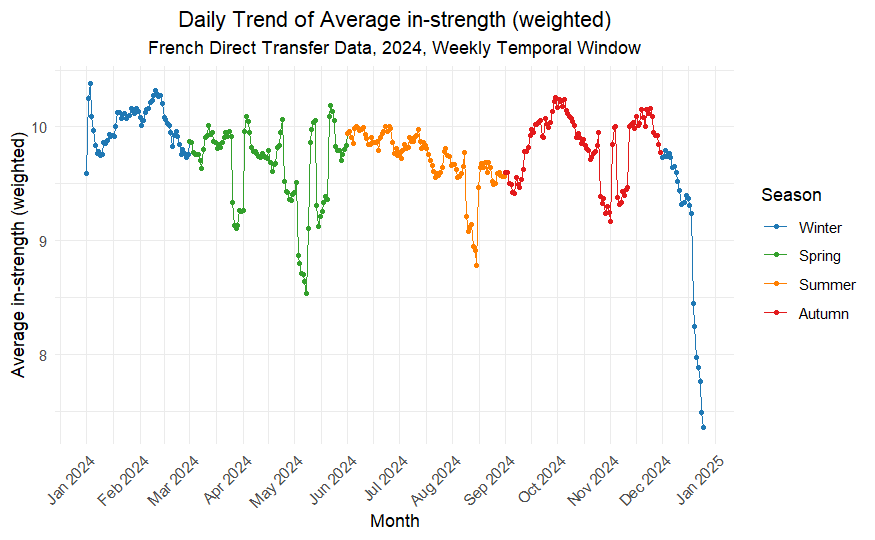

```
<img src=\data:…
```

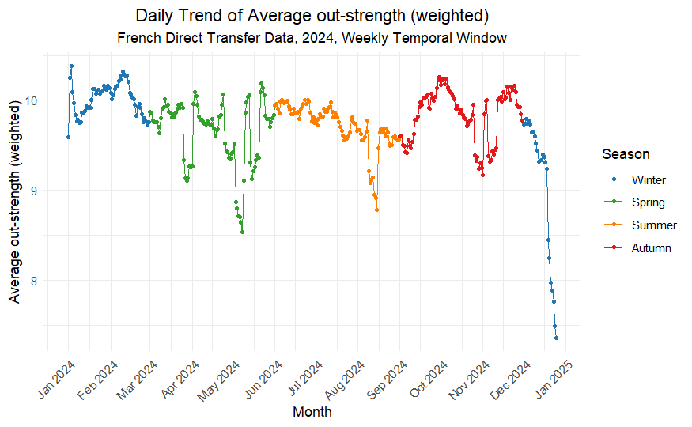

```
<img src=\data:…
```

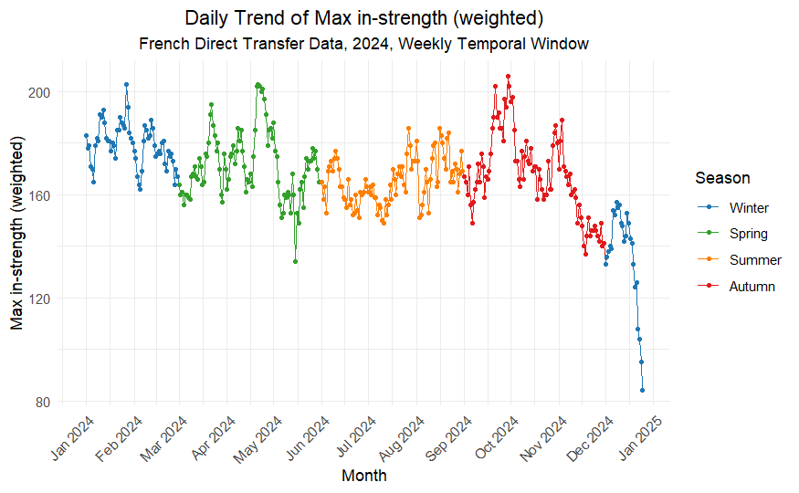

```
<img src=\data:…
```

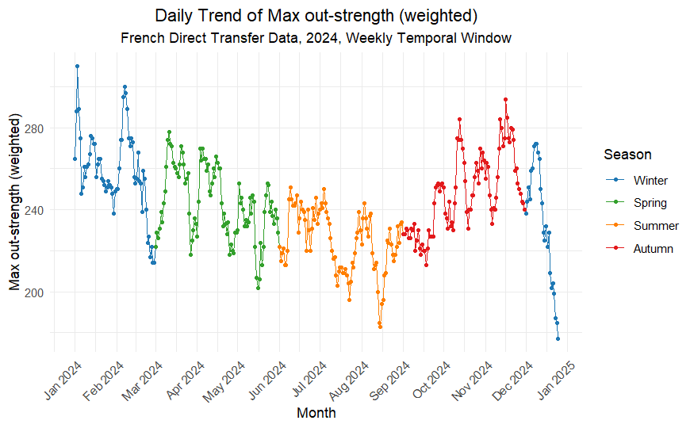

```
<img src=\data:…
```

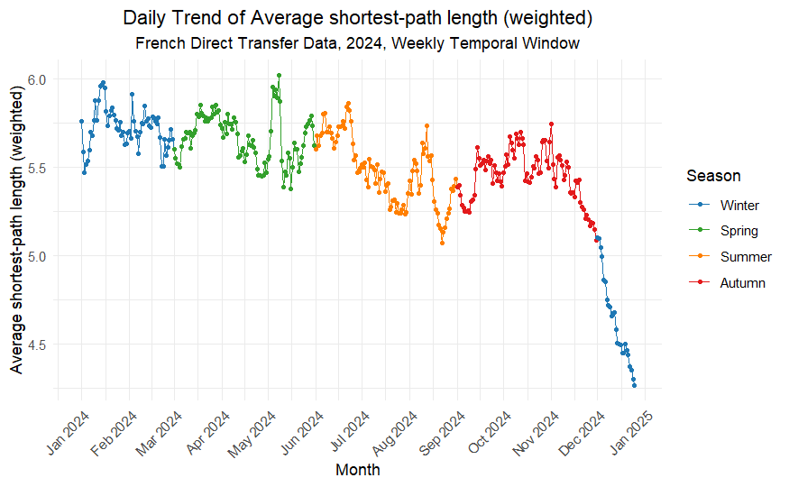

```
<img src=\data:…
```

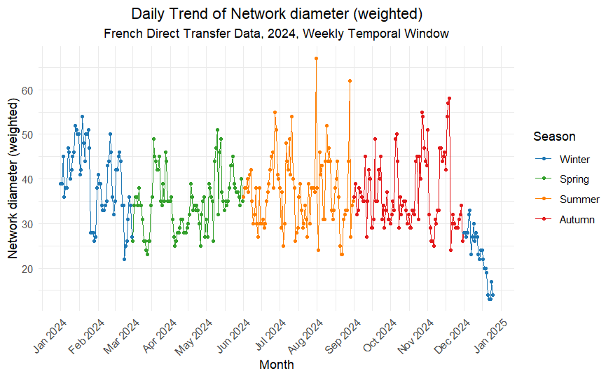

```
<img src=\data:…
```

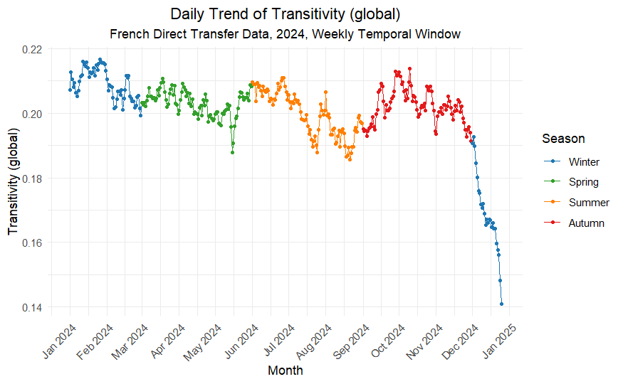

```
<img src=\data:…
```

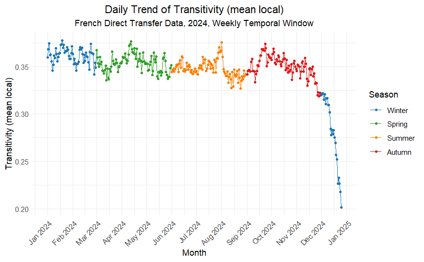

```
<img src=\data:…
```

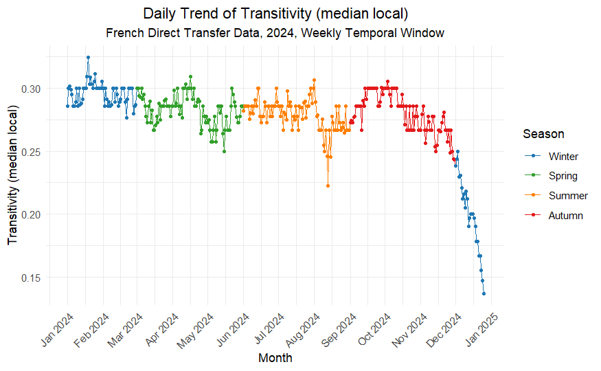

```
<img src=\data:…
```

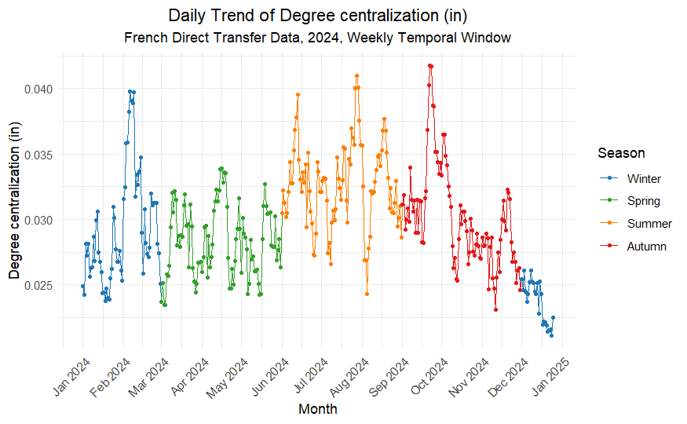